# cifar10_keras

## CNN visualization of Cifar10 using keras

zx2229

We have used tensorflow to do visualization of Cifar10 datasets. Since there are many visualization tools in keras, so it will be easier to use keras to do visualization on Cifar10 dataset. Here we will skip some parts we have introduded in tensorflow model part.The code here we refer to the book [*Deep learning with python*](https://www.manning.com/books/deep-learning-with-python).

### Load Cifar10 dataset

You should download the dataset into assigned path to load data

```python
import cifar10
import dataset
import cache
```

```python
cifar10.data_path = "./data/CIFAR-10/"
class_name = cifar10.load_class_names()
print(class_name)
```

```
Loading data: ./data/CIFAR-10/cifar-10-batches-py/batches.meta
['airplane', 'automobile', 'bird', 'cat', 'deer', 'dog', 'frog', 'horse', 'ship', 'truck']
```

```python
train_images_cifar10, train_class_cifar10, train_labels_cifar10 = cifar10.load_training_data()
test_images_cifar10, test_class_cifar10, test_labels_cifar10 = cifar10.load_test_data()
```

```
Loading data: ./data/CIFAR-10/cifar-10-batches-py/data_batch_1
Loading data: ./data/CIFAR-10/cifar-10-batches-py/data_batch_2
Loading data: ./data/CIFAR-10/cifar-10-batches-py/data_batch_3
Loading data: ./data/CIFAR-10/cifar-10-batches-py/data_batch_4
Loading data: ./data/CIFAR-10/cifar-10-batches-py/data_batch_5
Loading data: ./data/CIFAR-10/cifar-10-batches-py/test_batch
```

```python
print("Size for the training images: {0}".format(len(train_images_cifar10)))
print("Shape for the training images: {0}".format(train_images_cifar10.shape))
print("Shape for the training labels: {0}".format(train_labels_cifar10.shape))
print("Size for the test images: {0}".format(len(test_images_cifar10)))
print("Shape for the test images: {0}".format(test_images_cifar10.shape))
print("Shape for the test labels: {0}".format(test_labels_cifar10.shape))
```

```
Size for the training images: 50000
Shape for the training images: (50000, 32, 32, 3)
Shape for the training labels: (50000, 10)
Size for the test images: 10000
Shape for the test images: (10000, 32, 32, 3)
Shape for the test labels: (10000, 10)
```

### 1.Triain model

We trained two CNN models here for cifar10 data in this part. The first one has exactly the same structure as the one we trained in tensorflow, which is saved as **keras_cifar10_trained_model**, and the other one is from the keras official team,[cifar10_cnn](https://github.com/keras-team/keras/blob/master/examples/cifar10_cnn.py), which is saved as **keras_cifar10_trained_model_2**, both of them are in the file **keras_saved_models**. The latter one gets a 79% classfication accuracy result after 50 epochs, each of which has 1000 steps.Since the goal here is to do visualization on features and try to find the pattern, the performance of the CNN model here is not that important.We have comment out the code here, but you can retrain this part if you want, or you can directly load our trained model.

```python
# '''Train a simple deep CNN on the CIFAR10 small images dataset.

# It gets to 75% validation accuracy in 25 epochs, and 79% after 50 epochs.
# (it's still underfitting at that point, though).
# '''

# from __future__ import print_function
# import keras
# from keras.datasets import cifar10
# from keras.preprocessing.image import ImageDataGenerator
# from keras.models import Sequential
# from keras.layers import Dense, Dropout, Activation, Flatten
# from keras.layers import Conv2D, MaxPooling2D
# import os

# batch_size = 32
# num_classes = 10
# epochs = 50
# data_augmentation = True
# num_predictions = 20
# save_dir = os.path.join(os.getcwd(), 'keras_saved_models')
# model_name = 'keras_cifar10_trained_model_2.h5'

# # The data, split between train and test sets:
# (x_train, y_train), (x_test, y_test) = cifar10.load_data()
# print('x_train shape:', x_train.shape)
# print(x_train.shape[0], 'train samples')
# print(x_test.shape[0], 'test samples')

# # Convert class vectors to binary class matrices.
# y_train = keras.utils.to_categorical(y_train, num_classes)
# y_test = keras.utils.to_categorical(y_test, num_classes)

# ################### the CNN model from keras official team ###############

# model = Sequential()
# model.add(Conv2D(32, (3, 3), padding='same',
#                  input_shape=x_train.shape[1:]))
# model.add(Activation('relu'))
# model.add(Conv2D(32, (3, 3)))
# model.add(Activation('relu'))
# model.add(MaxPooling2D(pool_size=(2, 2)))
# model.add(Dropout(0.25))

# model.add(Conv2D(64, (3, 3), padding='same'))
# model.add(Activation('relu'))
# model.add(Conv2D(64, (3, 3)))
# model.add(Activation('relu'))
# model.add(MaxPooling2D(pool_size=(2, 2)))
# model.add(Dropout(0.25))

# model.add(Flatten())
# model.add(Dense(512))
# model.add(Activation('relu'))
# model.add(Dropout(0.5))
# model.add(Dense(num_classes))
# model.add(Activation('softmax'))

# ############## Exactly the same as  the cnn model trained in tensorflow ########################

# # n1 = 32
# # n2 = 64
# # n3 = 1024
# # n4 = 512

# # model = Sequential()
# # model.add(Conv2D(n1, (5, 5), input_shape=x_train.shape[1:], activation='relu', padding='same', name='conv1'))
# # model.add(MaxPooling2D(pool_size=(2, 2), strides=(2, 2), padding='same', name='pool1'))
# # model.add(Conv2D(n2, (5, 5), activation='relu', padding='same', name='conv2'))
# # model.add(MaxPooling2D(pool_size=(2, 2), strides=(2, 2), padding='same', name='pool2'))
# # model.add(Flatten())
# # model.add(Dense(n3, activation='relu', name='fc1'))
# # model.add(Dense(n4, activation='relu', name='fc2'))
# # model.add(Dropout(0.5, noise_shape=None, seed=None))
# # model.add(Dense(10, activation='softmax', name='preds'))
# ######################################################################################################

# # initiate RMSprop optimizer
# opt = keras.optimizers.rmsprop(lr=0.0001, decay=1e-6)

# # Let's train the model using RMSprop
# model.compile(loss='categorical_crossentropy',
#               optimizer=opt,
#               metrics=['accuracy'])

# x_train = x_train.astype('float32')
# x_test = x_test.astype('float32')
# x_train /= 255
# x_test /= 255

# if not data_augmentation:
#     print('Not using data augmentation.')
#     model.fit(x_train, y_train,
#               batch_size=batch_size,
#               epochs=epochs,
#               validation_data=(x_test, y_test),
#               shuffle=True)
# else:
#     print('Using real-time data augmentation.')
#     # This will do preprocessing and realtime data augmentation:
#     datagen = ImageDataGenerator(
#         featurewise_center=False,  # set input mean to 0 over the dataset
#         samplewise_center=False,  # set each sample mean to 0
#         featurewise_std_normalization=False,  # divide inputs by std of the dataset
#         samplewise_std_normalization=False,  # divide each input by its std
#         zca_whitening=False,  # apply ZCA whitening
#         zca_epsilon=1e-06,  # epsilon for ZCA whitening
#         rotation_range=0,  # randomly rotate images in the range (degrees, 0 to 180)
#         # randomly shift images horizontally (fraction of total width)
#         width_shift_range=0.1,
#         # randomly shift images vertically (fraction of total height)
#         height_shift_range=0.1,
#         shear_range=0.,  # set range for random shear
#         zoom_range=0.,  # set range for random zoom
#         channel_shift_range=0.,  # set range for random channel shifts
#         # set mode for filling points outside the input boundaries
#         fill_mode='nearest',
#         cval=0.,  # value used for fill_mode = "constant"
#         horizontal_flip=True,  # randomly flip images
#         vertical_flip=False,  # randomly flip images
#         # set rescaling factor (applied before any other transformation)
#         rescale=None,
#         # set function that will be applied on each input
#         preprocessing_function=None,
#         # image data format, either "channels_first" or "channels_last"
#         data_format=None,
#         # fraction of images reserved for validation (strictly between 0 and 1)
#         validation_split=0.0)

#     # Compute quantities required for feature-wise normalization
#     # (std, mean, and principal components if ZCA whitening is applied).
#     datagen.fit(x_train)

#     # Fit the model on the batches generated by datagen.flow().
#     model.fit_generator(datagen.flow(x_train, y_train,
#                                      batch_size=batch_size),
#                         steps_per_epoch = 1000,
#                         epochs=epochs,
#                         validation_data=(x_test, y_test),
#                         workers=4)

# # Save model and weights
# if not os.path.isdir(save_dir):
#     os.makedirs(save_dir)
# model_path = os.path.join(save_dir, model_name)
# model.save(model_path)
# print('Saved trained model at %s ' % model_path)

# # Score trained model.
# scores = model.evaluate(x_test, y_test, verbose=1)
# print('Test loss:', scores[0])
# print('Test accuracy:', scores[1])
```

```python
import keras
keras.__version__
```

```
'2.2.4'
```

### 2. Import trained model

We trained two keras models in previous steps, and we use the second one, which is from the keras official team here.

```python
from keras.models import load_model

model = load_model('./keras_saved_models/keras_cifar10_trained_model_2.h5')
model.summary()  # As a reminder to show the strucure of CNN model.
```

```
_________________________________________________________________
Layer (type)                 Output Shape              Param #
=================================================================
conv2d_5 (Conv2D)            (None, 32, 32, 32)        896
_________________________________________________________________
activation_7 (Activation)    (None, 32, 32, 32)        0
_________________________________________________________________
conv2d_6 (Conv2D)            (None, 30, 30, 32)        9248
_________________________________________________________________
activation_8 (Activation)    (None, 30, 30, 32)        0
_________________________________________________________________
max_pooling2d_3 (MaxPooling2 (None, 15, 15, 32)        0
_________________________________________________________________
dropout_7 (Dropout)          (None, 15, 15, 32)        0
_________________________________________________________________
conv2d_7 (Conv2D)            (None, 15, 15, 64)        18496
_________________________________________________________________
activation_9 (Activation)    (None, 15, 15, 64)        0
_________________________________________________________________
conv2d_8 (Conv2D)            (None, 13, 13, 64)        36928
_________________________________________________________________
activation_10 (Activation)   (None, 13, 13, 64)        0
_________________________________________________________________
max_pooling2d_4 (MaxPooling2 (None, 6, 6, 64)          0
_________________________________________________________________
dropout_8 (Dropout)          (None, 6, 6, 64)          0
_________________________________________________________________
flatten_5 (Flatten)          (None, 2304)              0
_________________________________________________________________
dense_3 (Dense)              (None, 512)               1180160
_________________________________________________________________
activation_11 (Activation)   (None, 512)               0
_________________________________________________________________
dropout_9 (Dropout)          (None, 512)               0
_________________________________________________________________
dense_4 (Dense)              (None, 10)                5130
_________________________________________________________________
activation_12 (Activation)   (None, 10)                0
=================================================================
Total params: 1,250,858
Trainable params: 1,250,858
Non-trainable params: 0
_________________________________________________________________
```

### 3. Feature Visualization

When fed an image input, above model returns the values of the layer activations in the original model. We will use one picture here to do feature visualization. In this part, we managed to do visualizaiton on trained CNN model,including each layer's visualization and activation maximization.

```python
# We preprocess the image into a 4D tensor
from keras.preprocessing import image
import numpy as np
img = train_images_cifar10[1]
img_tensor = image.img_to_array(img)
img_tensor = np.expand_dims(img_tensor, axis=0)
# Remember that the model was trained on inputs
# that were preprocessed in the following way:
print(img_tensor.shape)
```

```
(1, 32, 32, 3)
```

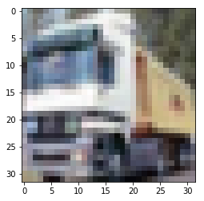

```python
# Use one image to do visualizaion
import matplotlib.pyplot as plt
plt.imshow(img_tensor[0])
plt.show() # original image
```

```python
from keras import models

# Extracts the outputs of the top 19 layers:
layer_outputs = [layer.output for layer in model.layers[:19]]
# Creates a model that will return these outputs, given the model input:
activation_model = models.Model(inputs=model.input, outputs=layer_outputs)
```

```python
# This will return a list of 18 Numpy arrays:
# one array per layer activation
activations = activation_model.predict(img_tensor)
len(activations)
```

```
18
```

```python
# the first layer activation dimesion
first_layer_activation = activations[0]
print(first_layer_activation.shape)
```

```
(1, 32, 32, 32)
```

We can see that the first feature map is a 32*32 feature map with 32 channels. Let's try visualizing the 3rd channel:

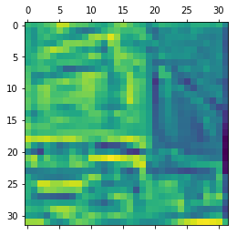

```python
import matplotlib.pyplot as plt

plt.matshow(first_layer_activation[0, :, :, 3], cmap='viridis')
plt.show()
```

The visualizaiton of the 30th channel:

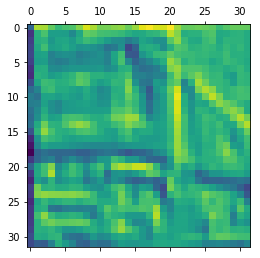

```python
plt.matshow(first_layer_activation[0, :, :, 30], cmap='viridis')
plt.show()
```

#### Each layer's visualization

[output not shown]

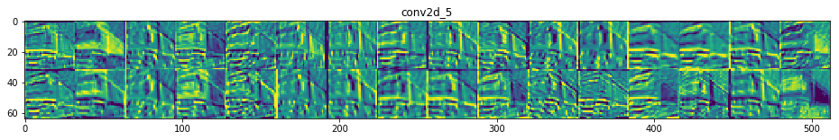

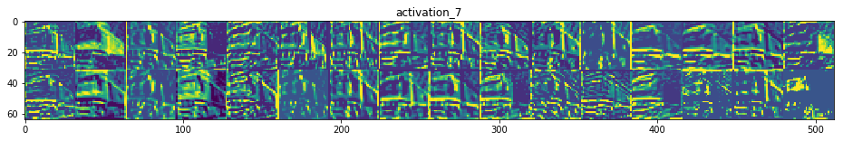

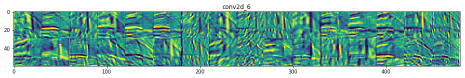

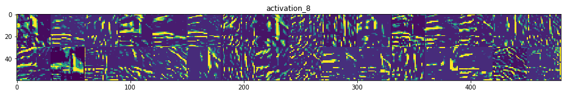

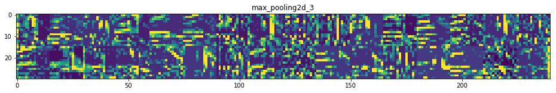

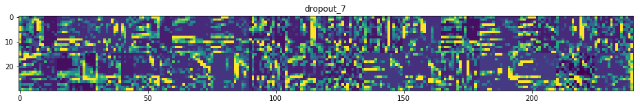

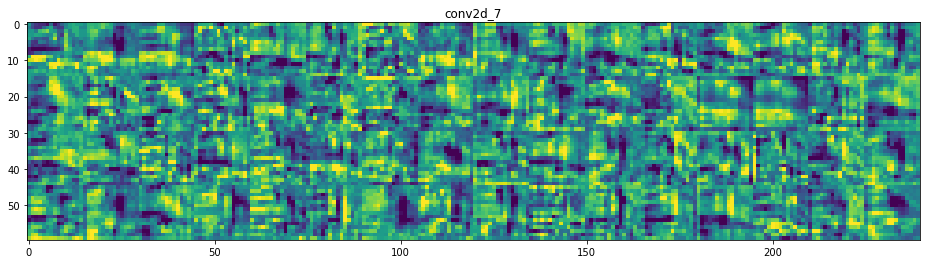

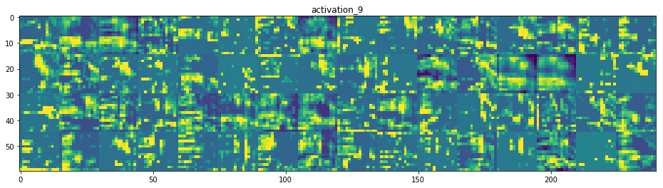

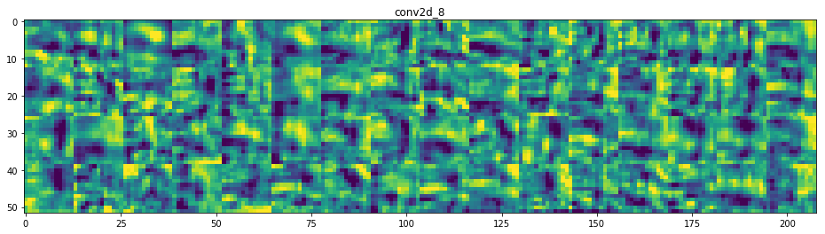

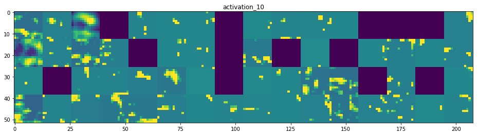

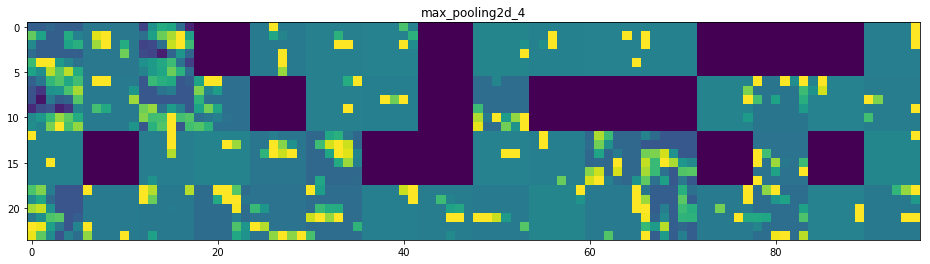

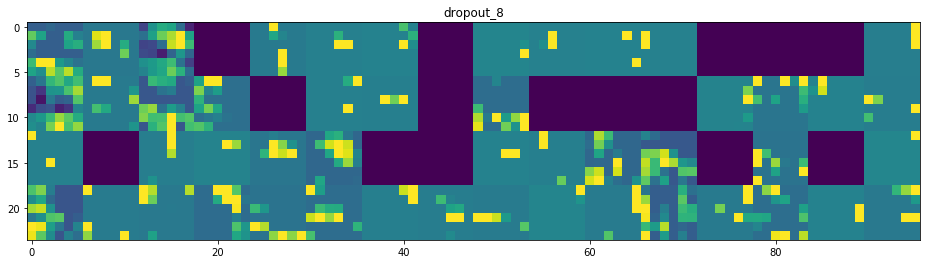

```python
import keras
import warnings
warnings.filterwarnings('ignore')
# These are the names of the layers, so can have them as part of our plot
layer_names = []
for layer in model.layers[:18]:
    layer_names.append(layer.name)

images_per_row = 16

# Now let's display our feature maps
for layer_name, layer_activation in zip(layer_names, activations):
    # This is the number of features in the feature map
    n_features = layer_activation.shape[-1]

    # The feature map has shape (1, size, size, n_features)
    size = layer_activation.shape[1]

    # We will tile the activation channels in this matrix
    n_cols = n_features // images_per_row
    display_grid = np.zeros((size * n_cols, images_per_row * size))

    # We'll tile each filter into this big horizontal grid
    for col in range(n_cols):
        for row in range(images_per_row):
            channel_image = layer_activation[0,
                                             :, :,
                                             col * images_per_row + row]
            # Post-process the feature to make it visually palatable
            channel_image -= channel_image.mean()
            channel_image /= channel_image.std()
            channel_image *= 64
            channel_image += 128
            channel_image = np.clip(channel_image, 0, 255).astype('uint8')
            display_grid[col * size : (col + 1) * size,
                         row * size : (row + 1) * size] = channel_image

    # Display the grid
    scale = 1. / size
    plt.figure(figsize=(scale * display_grid.shape[1],
                        scale * display_grid.shape[0]))
    plt.title(layer_name)
    plt.grid(False)
    plt.imshow(display_grid, aspect='auto', cmap='viridis')

plt.show()
```

This part we visualized each layer of the whole CNN model.Same as the result of model implemented by Tensorflow, we can find that:

- The first layer acts as a collection of various edge detectors. At that stage, the activations are still retaining almost all of the information present in the initial picture.
- As we go higher-up, the activations become increasingly abstract and less visually interpretable. They start encoding higher-level concepts. Higher-up presentations carry increasingly less information about the visual contents of the image, and increasingly more information related to the class of the image.
- The sparsity of the activations is increasing with the depth of the layer: in the first layer, all filters are activated by the input image, but in the following layers more and more filters are blank. This means that the pattern encoded by the filter isn't found in the input image.

#### Activation Maximization

```python
from keras import backend as K

layer_name = 'conv2d_5'
filter_index = 0

layer_output = model.get_layer(layer_name).output
loss = K.mean(layer_output[:, :, :, filter_index])
```

To implement gradient descent, we will need the gradient of this loss with respect to the model's input. To do this, we will use the gradients function packaged with the backend module of Keras:

```python
# The call to `gradients` returns a list of tensors (of size 1 in this case)
# hence we only keep the first element -- which is a tensor.
grads = K.gradients(loss, model.input)[0]
```

A non-obvious trick to use for the gradient descent process to go smoothly is to normalize the gradient tensor, by dividing it by its L2 norm (the square root of the average of the square of the values in the tensor). This ensures that the magnitude of the updates done to the input image is always within a same range.

```python
# We add 1e-5 before dividing so as to avoid accidentally dividing by 0.
grads /= (K.sqrt(K.mean(K.square(grads))) + 1e-5)
```

Now we need a way to compute the value of the loss tensor and the gradient tensor, given an input image. We can define a Keras backend function to do this: iterate is a function that takes a Numpy tensor (as a list of tensors of size 1) and returns a list of two Numpy tensors: the loss value and the gradient value.

```python
iterate = K.function([model.input], [loss, grads])

# Let's test it:
import numpy as np
loss_value, grads_value = iterate([np.zeros((1, 150, 150, 3))])
```

At this point we can define a Python loop to do stochastic gradient descent:

```python
# We start from a gray image with some noise
input_img_data = np.random.random((1, 32, 32, 3)) * 20 + 128.

# Run gradient ascent for 40 steps
step = 1.  # this is the magnitude of each gradient update
for i in range(40):
    # Compute the loss value and gradient value
    loss_value, grads_value = iterate([input_img_data])
    # Here we adjust the input image in the direction that maximizes the loss
    input_img_data += grads_value * step
```

```python
def deprocess_image(x):
    # normalize tensor: center on 0., ensure std is 0.1
    x -= x.mean()
    x /= (x.std() + 1e-5)
    x *= 0.1

    # clip to [0, 1]
    x += 0.5
    x = np.clip(x, 0, 1)

    # convert to RGB array
    x *= 255
    x = np.clip(x, 0, 255).astype('uint8')
    return x
```

Now we have all the pieces, let's put them together into a Python function that takes as input a layer name and a filter index, and that returns a valid image tensor representing the pattern that maximizes the activation the specified filter:

```python
def generate_pattern(layer_name, filter_index, size=32):
    # Build a loss function that maximizes the activation
    # of the nth filter of the layer considered.
    layer_output = model.get_layer(layer_name).output
    loss = K.mean(layer_output[:, :, :, filter_index])

    # Compute the gradient of the input picture wrt this loss
    grads = K.gradients(loss, model.input)[0]

    # Normalization trick: we normalize the gradient
    grads /= (K.sqrt(K.mean(K.square(grads))) + 1e-5)

    # This function returns the loss and grads given the input picture
    iterate = K.function([model.input], [loss, grads])

    # We start from a gray image with some noise
    input_img_data = np.random.random((1, size, size, 3)) * 20 + 128.

    # Run gradient ascent for 40 steps
    step = 1.
    for i in range(40):
        loss_value, grads_value = iterate([input_img_data])
        input_img_data += grads_value * step

    img = input_img_data[0]
    return deprocess_image(img)
```

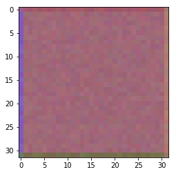

```python
plt.imshow(generate_pattern('conv2d_5', 0))
plt.show() #
```

We can start visualising images which maximumly activate each unit in each convolutional layer .

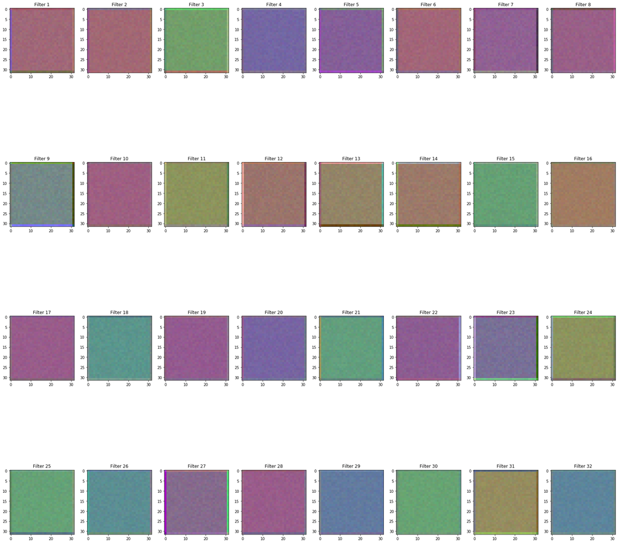

```python
# Show the input image that maximaly activate the 32 filters in conv1.
plt.figure(1, figsize=(30,30))
n_columns = 8
n_rows = 4
for i in range(32):
    plt.subplot(n_rows, n_columns, i+1)
    plt.title('Filter ' + str(i+1))
    plt.imshow(generate_pattern('conv2d_5', i))
```

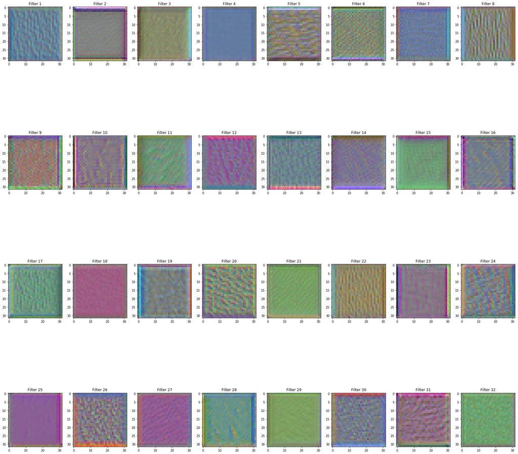

```python
# Show the input image that maximaly activate the 32 filters in conv2.
plt.figure(1, figsize=(30,30))
n_columns = 8
n_rows = 4
for i in range(32):
    plt.subplot(n_rows, n_columns, i+1)
    plt.title('Filter ' + str(i+1))
    plt.imshow(generate_pattern('conv2d_6', i))
```

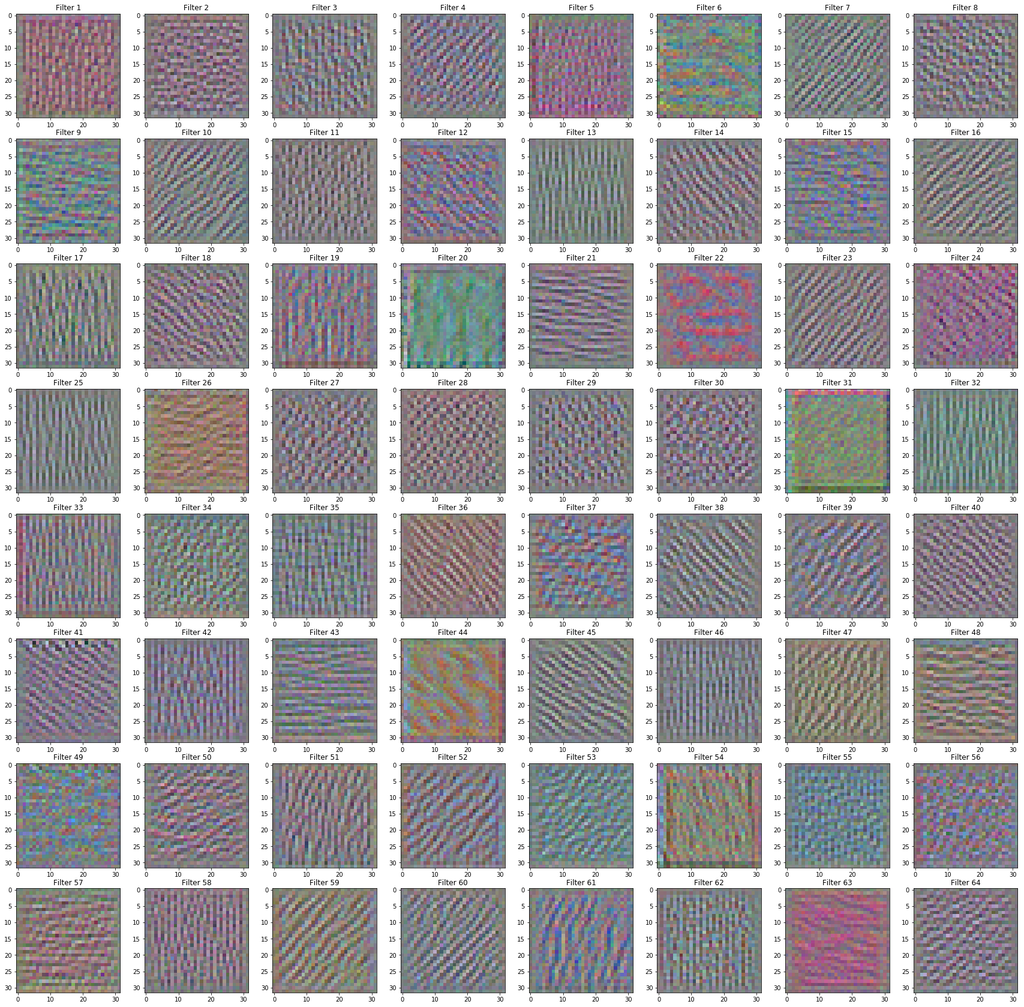

```python
# Show the input image that maximaly activate the 64 filters in conv3.
plt.figure(1, figsize=(30,30))
n_columns = 8
n_rows = 8
for i in range(64):
    plt.subplot(n_rows, n_columns, i+1)
    plt.title('Filter ' + str(i+1))
    plt.imshow(generate_pattern('conv2d_7', i))
```

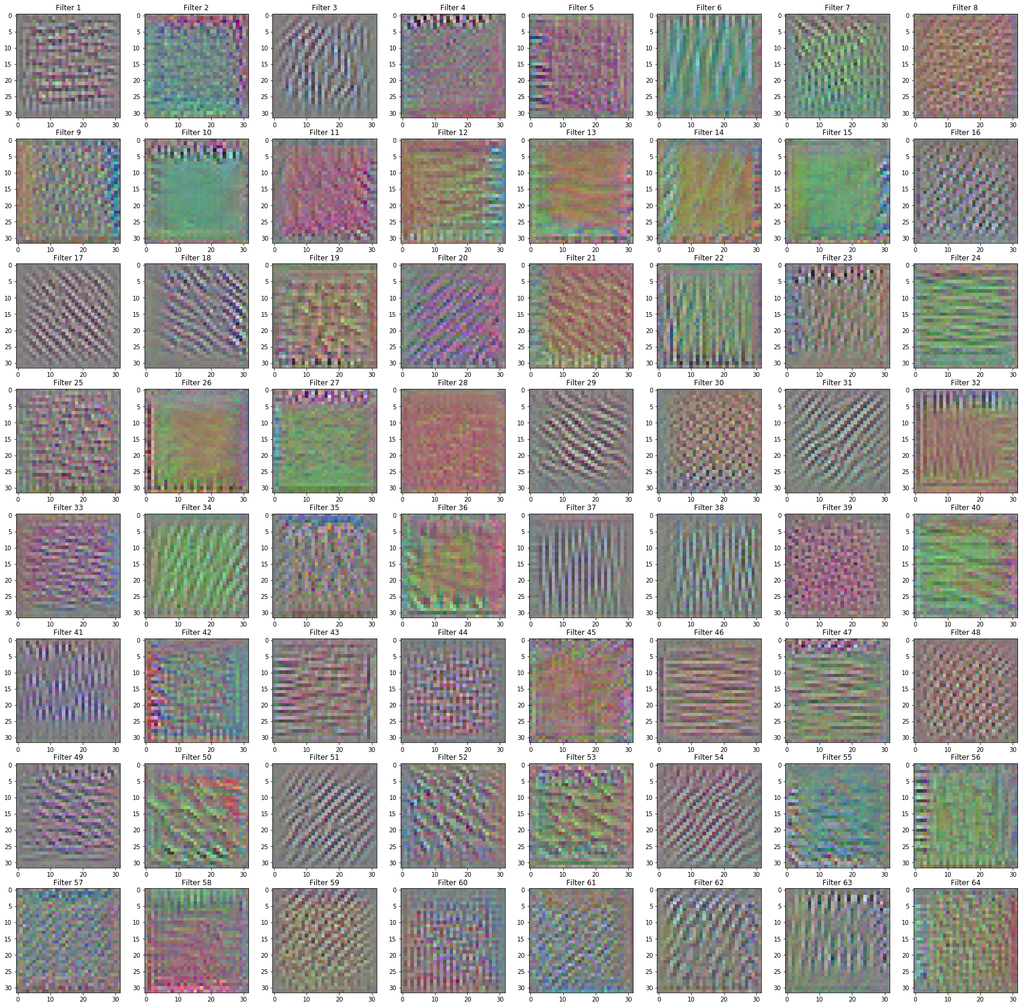

```python
# Show the input image that maximaly activate the 64 filters in conv4.
plt.figure(1, figsize=(30,30))
n_columns = 8
n_rows = 8
for i in range(64):
    plt.subplot(n_rows, n_columns, i+1)
    plt.title('Filter ' + str(i+1))
    plt.imshow(generate_pattern('conv2d_8', i))
```